# **Лекция 1. Рынок информационных ресурсов**

- Определение и классификация информационных ресурсов
- Рынок информационных ресурсов
- Управление ИР - аналитика больших данных

## Определение и классификация информационных ресурсов

Любой субъект (мировое сообщество, конкретное государство, регион, город или район, организация, предприятие или хозяйство, отдельный человек или группа лиц) для своей деятельности располагает определенными объемами и видами ресурсов.

Последние подразделяются на отдельные виды ресурсов относительно определенных предметных областей жизни и деятельности человека. Например:

- материальные (совокупность предметов труда, используемых в процессе производства общественного продукта — сырье материалы, топливо, полуфабрикаты и т. п.),
- природные (естественные ресурсы — объекты, процессы, условия природы, используемые для удовлетворения материальных и духовных потребностей людей),
- энергетические (носители энергии — нефть, газ и др.),
- трудовые (люди, владеющие общеобразовательными и профессиональными знаниями),
- финансовые, товарные, нематериальные (духовные или интеллектуальные) и др.

Перечисленные ресурсы имеют первостепенное значение для материального производства особенно в эпоху индустриального общества.

В отличие от большинства перечисленных выше ресурсов информационные ресурсы (ИР) являются продуктом интеллектуальной деятельности наиболее квалифицированной и творческой части населения, составляют значительную часть национального богатства и относятся к числу возобновляемых благ, так как имеют способность к тиражированию в зависимости от общественной потребности.

В большей своей части эти ресурсы материализованы в виде книг, статей, документов, баз данных, баз знаний, алгоритмов, компьютерных программ, произведений искусства, литературы и т.п. По существу, эти накопленные людьми знания на протяжении своей истории существования и развития, зачастую отчужденные от своих создателей, рассматриваются как общие стратегические ресурсы, принадлежащие всему человечеству.

Информационные ресурсы объединяют первичную информацию, отражающую знания человека об опыте своей деятельности и сведения об окружающей среде, а также всю вторичную информацию, образующуюся в результате обработки и переработки всей получаемой информации.

С одной стороны определенный объем ИР составляют знания людей, специалистов (экспертные знания). Объем этих знаний неуклонно возрастает в результате более совершенных и целенаправленных научных исследований, ведущих к открытиям и научно-техническим достижениям, более глубокого и широкого образования населения, развития и повсеместно используемых современных средств вычислительной техники, коммуникаций, связи и других факторов.

С другой стороны, основная и большая часть ресурсов представляет собой накопленную информацию, которая фиксировалась на различных носителях на протяжении всего исторического пути развития человечества и продолжает накапливаться и фиксироваться в настоящее время весьма быстрыми темпами (за счет использования современных компьютерных и коммуникационных средств).

Следует отметить, что обмен информацией в результате общения и коммуникаций присущ всей живой природе (по некоторым учениям нематериалистического характера и неживой), однако только человеку принадлежит свойство глубокого познания окружающего мира, извлечения из него разнообразной информации, ее анализа и на этой базе генерирования и накапливания новых знаний. Именно это - формирование и использование ИР - отличает человека от всего живого и позволяет ему не только осознанно ориентироваться в окружающей обстановке, но и создавать вокруг себя общественные богатства, строить социальные отношения и обеспечивать свою жизнедеятельность с помощью научно-технических достижений.

Чрезвычайно важно то обстоятельство, что определенным образом собранная и целенаправленно обработанная информация порождает новые знания. Таким образом, информация обладает уникальным свойством репродуцировать (воспроизводить) знания и усиливать эффект их накопления (суммирования), что приводит к постоянному росту ИР.

Следует отметить, что практически до последней четверти ХХ в. ИР не рассматривались с позиций общественно значимой экономической или иной категории, влияющей на состояние и развитие страны. В основном обращалось внимание на культурное наследие той или иной национальности или государства. В настоящее время в эпоху постиндустриального развития общества по своей эффективности использования, важности, полезности и степени значимости ИР играют все большую роль и рассматриваются как приоритетные стратегические ресурсы, сопоставимые с материальными и энергетическими ресурсами.

В современной редакции Закона "Об информации, информационных технологиях и о защите информации" по сравнению со старой понятие информационного ресурса не приводится, однако в виду важности этого понятия приведем его определение согласно старому закону:

**Информационный ресурс**- *отдельные документы и отдельные массивы документов, документы и массивы документов в информационных системах (библиотеках, архивах, фондах, банках данных, других информационных системах).*

Учитывая, что эта формулировка носит статический характер наличия или хранения сведений и не затрагивает большую и чрезвычайно важную часть знаний, которыми обладают отдельные люди, образованные и информированные в определенных областях науки и техники, медицины и биологии, литературы и искусства и т. д. (учителя, врачи, ученые, инженеры и т. д., одним словом, эксперты), целесообразно понятие ИР представить шире с учетом динамических свойств, рассматриваемых в моменты передачи информации и ее восприятия. Отсюда это понятие можно представить так:

**Информационный ресурс**— это индивидуальные и коллективные экспертные знания, отдельные документы, отдельные массивы документов, а также документы и их массивы, составляющие базы и банки данных, базы знаний, библиотеки, архивы, фонды, информационные системы и другие системы в определенной предметной тематической области, которые удовлетворяют функциональным потребностям и запросам потребителей информации.

Информационными ресурсами обладают отдельные люди, коллективы людей, организации, территориальные и национальные образования, города, регионы, страны и в целом весь мир. Если ИР собирается и используется в рамках региона или в рамках одной страны, то говорят о региональных или национальных, государственных ИР.

Государственные информационные ресурсы в России включают:

- федеральные информационные ресурсы;
- информационные ресурсы, находящиеся в совместном ведении Российской Федерации и субъектов Российской Федерации (информационные ресурсы совместного ведения);
- информационные ресурсы субъектов Российской Федерации.

В том случае если информация пересекает государственные границы и используется на межгосударственном или межнациональном уровне, то говорят о мировых информационных ресурсах. Учитывая развитие современных информационных технологий, прежде всего повсеместное расширение в мире глобальной сети Интернет, государственные границы для информации теряют свое значение, и она становится доступной для всего человечества. Поэтому вся совокупность ИР, накопленных различными лицами, организациями, регионами, государствами и используемых на межгосударственном уровне, называется **мировыми информационными ресурсами**.

За последние годы широкое использование компьютеров и микропроцессоров, сетей передачи данных, спутниковых и наземных каналов связи позволило объединить мир в единую гигантскую систему, практически не имеющую границ и обеспечивающую хранение колоссальных по объему разнообразных ИР, пополнение и широкие возможности их освоения. Разрабатываются новые методы, оптимизирующие процессы обработки информации (например, распараллеливание процессов), ее хранения (например, сжатие) и распространения.

Происходит переход к "безбумажной" технологии и "безбумажному" обществу, в котором ИР представляются в основном в цифровом или электронном виде, а информационный обмен между людьми осуществляется с помощью электронных средств (Интернета, электронной почты, видеотелефона, видеоконференций, факсимильной связи и т. п.). Хранение и обработка любой информации при этом производится в цифровом виде на персональных компьютерах (объединенных развитой телекоммуникационной сетью), что по своей сути является переходом к новой - шестой фазе развития и потребления ИР.

Современные информационные технологии по формированию и использованию ИР привели к созданию информационной индустрии, которая по своим масштабам и экономическим показателям опередила энергодобывающую, промышленную и сельскохозяйственную индустрии. Она связана как непосредственно с поиском и предоставлением информации, так и с разработкой программного и технического обеспечения и продажей его все большему числу пользователей. При этом возникла проблема экономической оценки как самих ИР, так процессов их хранений и передачи. Появились множественные службы и организации по управлению и распространению ИР, а также программных и технических средств их хранения, переработки и доставки.

В итоге развитие мировых ИР и эволюция информационных технологий на настоящий момент позволили:

- формировать новые ИР на базе более эффективных методов и средств автоматизации и информатизации;
- превратить деятельность по оказанию информационных услуг в глобальную человеческую деятельность;
- сформировать мировой и внутригосударственный рынок информационных услуг;
- образовать всевозможные базы данных по ресурсам регионов и государств;
- более эффективно использовать имеющиеся ИР для повышения обоснованности и оперативности принимаемых решений по управлению как в технических и организационно-экономических системах (например, в фирмах, банках, биржах, в промышленности, торговли и т.п.), так в социальной и других сферах.

Для классификации ИР и разбиения их на определенные виды или категории можно использовать разнообразные признаки. Наиболее обобщенным признаком служит признак формы представления или фиксации информации. В соответствии с этим признаком классификация ИР представлена на рисунке.

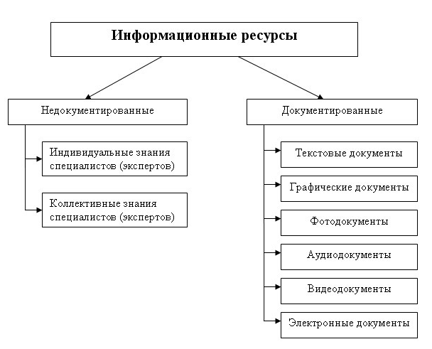

Исходя из приведенной классификации, все ИР целесообразно разбить на два класса: недокументированные, к которому относят индивидуальные и коллективные знания специалистов, и документированные.

Документированные ИР по признаку закрепления информации подразделяют на текстовые (письменные), графические(чертежи, схемы, графики, карты, диаграммы, картины), фото-, аудио- (грампластинки, аудиокассеты и т. п.), видео- (кинофильмы, диапозитивы, слайды и т. п.) и электронные документы.

По признаку фиксации информации документированные ИР можно также разделить на два класса: зафиксированная и хранящаяся на различного типа материальных носителях (различные материалы: бумага, холст, глина, парафин, фотопленка, кинопленка, магнитная пленка и т. п.) и преобразованная и зафиксированная в электронном виде (память компьютера, дискетка, компакт-диск и т.п.).

По признаку подлинности документированные ИР подразделяются на документы-оригиналы и копированные, или репродуцированные, документы (микрофиши, микрофильмы, ксерокопии. фотокопии и т.п.).

По признаку тематической принадлежности ИР могут быть подразделены на множество тематических областей и подоблестей знаний, например:

- научные ресурсы;
- социальные ресурсы;
- экологические ресурсы;
- законодательные ресурсы
- нормативно-правовые ресурсы;
- статистические ресурсы;
- обучающие ресурсы и т.д.

Использовать данный признак классификации ИР достаточно сложно, так как один и тот же ресурс может содержать информацию по ряду разнообразных тем. В таком случае ИР включают в соответствующие тематикам виды, и, таким образом, он может встречаться многократно в разных списках.

По признаку ограничения доступа ИР подразделяются на ряд классов, которые определяются законодательством страны или внутренними положениями организаций, владеющих информацией. Так, в Законе "Об информации, информационных технологиях и о защите информации" сказано, что "доступ к информации - это возможность получения информации и ее использования" (ст. 2, п. 6); "конфиденциальность информации — обязательное для выполнения лицом, получившим доступ к определенной информации, требование не передавать такую информацию третьим лицам без согласия ее обладателя" (ст. 2, п. 7); "ограничение доступа к информации устанавливается федеральными законами в целях защиты основ конституционного строя, нравственности, здоровья, прав и законных интересов других лиц, обеспечения обороны страны и безопасности государства" (ст. 9, п. 1).

Также в Законе прописано: "Информация в зависимости от категории доступа к ней подразделяется на общедоступную информацию, а также на информацию, доступ к которой ограничен федеральными законами (информация ограниченного доступа)" (ст. 5, п. 2) и "Информация в зависимости от порядка ее предоставления или распространения подразделяется:

- на информацию, свободно распространяемую;
- информацию, предоставляемую по соглашению лиц, участвующих в соответствующих отношениях;
- информацию, которая в соответствии с федеральными законами подлежит предоставлению или распространению;
- информацию, распространение которой в Российской Федерации ограничивается или запрещается" (ст. 5, п. 3).

Таким образом, информация в зависимости от категории доступа разбита на два класса: общедоступную информацию и информацию ограниченного доступа, и в зависимости от порядка ее предоставления или распространения — на 4 класса.

Следует отметить, что Закон гласит: "Федеральными законами устанавливаются условия отнесения информации к сведениям, составляющим коммерческую тайну, служебную тайну и иную тайну, обязательность соблюдения конфиденциальности такой информации, а также ответственность за ее разглашение" (ст. 9, п. 4).

По признаку коммерциализации ИР можно разделить:

- на некоммерческие ресурсы (открытые государственные и отраслевые публичные библиотеки, фонды, хранилища, музеи, передачи по общедоступным каналам эфирного или кабельного телевидения и радио, бесплатное образование и т. п.);
- коммерческие ресурсы (конкретный информационный продукт, имеющий определенную стоимость и продаваемый по рыночной цене, или платный доступ в библиотеки, фонды, хранилища, музеи, к системе платного телевидения, в информационные системы, в том числе Интернете и т.д.).

ИР от отправителя (коммуникатора) к потребителю (реципиенту) распространяются с помощью устных, документальных и электронных каналов передачи информации. При этом возможны четыре варианта коммерциализации процесса:

- предоставление ресурса бесплатно, получение бесплатное;
- предоставление ресурса бесплатное, получение платное;
- предоставление ресурса платное, получение бесплатное;
- предоставление ресурса платное, получение платное.

В рекламном бизнесе принято предоставлять ИР на платной основе, а получать рекламную информацию бесплатно (по телевидению и радио, путем рассылки газет, рекламных брошюр, установки рекламных щитов и плакатов и т. п.).

Для доступа в Интернет провайдерами устанавливается определенная плата в зависимости от объема получаемой информации или времени нахождения в сети. При этом отдельные ресурсы предоставляются бесплатно, а некоторые имеют свою цену, которую необходимо оплатить предварительно перед получением информации.

Информатизация общества с учетом индустриального развития и совершенствования методов и средств получения, обработки, преобразования, передачи и использования информации ведет к устранению человека от рутинных операций в работе, обеспечению высокого уровня автоматизации в производственной и социальной сферах, а значит, к снижению материала- и энергоемкости производства и повышению его эффективности, т.е. решающим образом влияет на уровень экономического развития страны, ее обороноспособность и на все стороны проявления социальной деятельности граждан.

В высокоразвитом информационном обществе должно измениться не только производство, но и весь уклад жизни, система ценностей, при которой возрастает значимость культурного досуга по отношению к материальным ценностям. По сравнению с индустриальным обществом, где все направлено на производство и потребление товаров, в информационном обществе производятся и потребляются интеллект, знания, что приводит к увеличению доли умственного труда. От человека потребуется способность к творчеству, возрастет спрос на знания.

Таким образом, деятельность людей будет сосредоточена главным образом на создании и использовании ИР, а производство материальных и энергетических ресурсов в большей своей части будет возложено на машины. В настоящее время закладываются основы построения единого мирового информационного пространства, объединяющего все человечество в информационное сообщество людей.

Материальной и технологической базой информационного общества являются различного рода системы на базе компьютерной техники и компьютерных сетей, информационной технологии, телекоммуникационной связи.

Ряд ученых выделяют характерные черты информационного общества:

- решена проблема информационного кризиса, т.е. разрешено противоречие между информационной лавиной и информационным голодом;
- обеспечен приоритет информации по сравнению с другими ресурсами, при этом главной формой развития станет информационная экономика;
- в основу общества будут заложены автоматизированные генерация, хранение, обработка и использование знаний с помощью новейшей информационной техники и технологии;
- информационная технология приобретет глобальный характер, охватывая все сферы социальной деятельности человека;
- формируется информационное единство всей человеческой цивилизации;
- с помощью средств информатики реализован свободный доступ каждого человека к информационным ресурсам всей цивилизации;
- реализованы гуманистические принципы управления обществом и воздействия на окружающую среду.

Кроме положительных моментов прогнозируются и опасные тенденции:

- все большее влияние на общество средств массовой информации;
- информационные технологии могут разрушить частную жизнь людей и организаций;
- существует проблема отбора качественной и достоверной информации;
- многим людям будет трудно адаптироваться к среде информационного общества;
- существует опасность разрыва между "информационной элитой" (людьми, занимающимися разработкой информационных технологий) и потребителями.

## Рынок информационных ресурсов

Информатизация общества неразрывно связана с возникновением и развитием рынка информационных продуктов и услуг, который представляет собой систему экономических, правовых и организационных отношений в сфере свободной купли-продажи товаров интеллектуального труда и услуг между различными субъектами хозяйствования и потребителями.

Этот рынок, как и другие рынки, характеризуется определенной номенклатурой продуктов и услуг, условиями и механизмами их предоставления, ценами.

Характерными чертами рыночных отношений являются: наличие конкуренции, свободный выбор партнеров, взаимные соглашения обменивающихся сторон, эквивалентный обмен товаров и денежных средств и т.д., что обеспечивает возможность эффективного решения социально-экономических проблем.

В качестве товаров интеллектуального труда на этом рынке выступают информационные продукты: знания, документы, информационные системы, информационные технологии, лицензии, патенты, товарные знаки, ноу-хау, инженерно-технические услуги, различного рода информация и прочие виды информационных ресурсов.

В рыночных понятиях товар интеллектуального труда имеет совокупность многих свойств, соответствующих товару материально-вещественной или энергетической формы, т. е. любому продукту труда, произведенного для купли-продажи (обмена) и являющемуся предметом торговли.

Понятию **информационная услуга** кроме основного определения — подготовку, получение и предоставление в распоряжение пользователя информационных ресурсов — можно дать следующие характеристики:

- результат информационной деятельности или информационных процессов;
- конкретный результат материального или духовного производства, обладающий качествами, характеризующими его целевое назначение, и информационными свойствами, ради которых он приобретается и потребляется;
- комплекс осязаемых и неосязаемых свойств (характеристик, функций, выгод и использований), предназначенных для удовлетворения информационных нужд покупателей;
- результат непроизводственной деятельности предприятия или лица, направленный на удовлетворение информационных потребностей человека или организации в использовании различных продуктов.

Уникальность информационных услуг предопределяет специфику рыночных отношений. Перечень предлагаемых на рынке информационных услуг определяется объемом, качеством, предметной ориентацией в сфере использования информационных ресурсов. Обобщая вышесказанное, понятие информационной услуги можно определить следующим образом:

**Информационная услуга** - удовлетворение со стороны информационной системы, собственника или владельца информационного ресурса заявки пользователя на подготовку и получение в согласованных условиях некоторого информационного ресурса определенной тематической направленности, заданного вида и конечного объема.

При предоставлении услуги заключается соглашение (договор) между двумя сторонами - предоставляющей и использующей услугу.

**Рынок информационных услуг** - совокупность отношений между потребителями (товаропроизводителями) и субъектами предложения, включающих взаимодействия по поводу производства, приобретения, использования информации путем консультаций, образовательной, издательской, рекламной и правовой деятельности.

Рынок информационных услуг в процессе своего функционирования выполняет шесть основных функций:

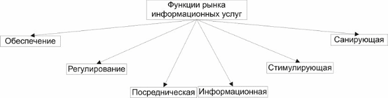

1) функция обеспечения - удовлетворяет потребности каждого участника либо в приобретении (получении), либо в сбыте информации; 2) функция регулирования: оптимально формирует структурные пропорции в общем объеме информационных услуг разного вида как с точки зрения спроса (потребления), так и с точки зрения их предложения; обеспечивает рациональное распределение и обмен информацией между всеми субъектами рынка; устанавливает уровень и зависимость движения цен (расценок) на информационные услуги под влиянием спроса и предложения; 3) посредническая функция - позволяет осуществлять обмен информационными услугами между поставщиками и потребителями; 4) информационная функция - обеспечивает распространение всей необходимой информации для активного и выгодного участия субъекта в рыночных отношениях; 5) стимулирующая функция: способствует повышению качества и расширению ассортимента информационных услуг на основе конкуренции; нацеливает поставщиков услуг на эффективную деятельность за счет изыскания наиболее оптимальных способов оказания услуг (достижение минимизации издержек при высоком качестве); 6) санирующая функция - повышает конкурентоспособность, в противном случае механизм конкурентной борьбы санирует рынок от неконкурентоспособных участников.

Потребителями информационных продуктов и услуг могут быть различные юридические и физические лица - специалисты, работающие почти во всех сферах производства и нуждающиеся в дополнительных знаниях. Они могут быть разделены на следующие группы:

- работники научно-исследовательских учреждений и учебных заведений;
- специалисты промышленных предприятий, фирм и предприятий торговли;
- специалисты консалтинговых и маркетинговых информационных агенств;
- работники государственных учреждений;
- работники общественных организаций;
- индивидуальные пользователи. Потребители информационных ресурсов нуждаются в информации, которую целесообразно разделить на следующие категории:

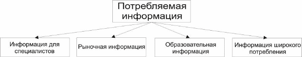

**Информация для специалистов** содержит научную, инженерно-техническую, конструкторскую, проектную, а также гуманитарную, т.е. профессиональную, информацию (документальную, библиографическую, реферативную, справочную) в области естественных, технических, общественных наук, по отраслям производства и сферам человеческой деятельности (в промышленности, сельском хозяйстве, вооруженных силах, окружающей среде, социальной сфере, медицине и здравоохранении, в сфере государственного управления, культуре и т.д.), предназначенную для узкого круга специалистов - ученых, инженеров, конструкторов, историков, юристов, врачей, геологов и т.д.

На стадии фундаментальных исследований необходима следующая научная и инженерно-техническая информация:

- сведения о последних достижениях науки и техники;
- информация о тенденциях развития данного вида техники;
- сведения о патентах;
- другие На стадии прикладных исследований, конструкторских разработок и технологического освоения требуется следующая информация:
- сведения о новых научно-технических достижениях и НИОКР;
- сведения о совокупности затрат на разработку и производство;
- описание техники возможного производства;
- характеристика периода морального старения объектов техники;
- данные о затратах на изготовление;
- сведения о сырье и оборудовании;
- предложения фирм по материалам, комплектующим изделиям;
- сведения по стандартизации, сертификации и т.д

На стадии производства идет отбор, анализ, внедрение научно-технической документации и оценка технических условий, что требует информации о мировых, региональных, национальных, отраслевых классификационных и оценочных показателях.

На стадиях эксплуатации, модернизации, утилизации необходима конъюнктурная и маркетинговая информация.

Кроме того, нужна правовая охрана промышленной и интеллектуальной собственности, создаваемой производителем, в том числе информации о патентной ситуации, о реализации патентирования, лицензирования, экспертизы; о целесообразности приобретения лицензий и "ноу-хау" других фирм; о возможности коммерческого использования интеллектуальных продуктов инновационного цикла: патенты изобретений, принципиальные схемы, публикации, макеты изделий, образцы, чертежно-конструкторская документация, технологические образцы, технологическая документация, эксплуатационная документация, технология утилизации, сведения о законодательных и нормативных актах и их практическом применении.

**Рыночная информация** состоит из биржевой и финансовой информации (котировки ценных бумаг, валютные курсы, учетные ставки, рынок товаров и капиталов, инвестиции, цены и т.п.), маркетинговой информации (структура рынка, сегмент предприятия на рынке, спрос, предложения, потребители, конкуренты, конкурирующие товары, поставщики, общеэкономические тенденции), коммерческой бизнес-информации (общая информация по финансовому рейтингу, финансовая информация по активам и пассивам фирмы, по обороту, по стоимости продаж, кредитно-аналитическая информация по ликвидности по коэффициентам рентабельности, платежно-аналитическая информация, сроки исполнения платежей, сведения о компаниях, фирмах, корпорациях, направлении работы и их продукции, ценах на продукцию; о финансовом состоянии, связях, сделках, руководителях, деловых новостей в области экономики и бизнеса и т.п.)

Основными потребителями биржевой информации в России являются профессиональные участники биржевого, фондового и финансового рынков - оптовики, профессиональные инвесторы, а также аналитические и консультационные службы, ориентированные на их обслуживание.

Специфика этого вида информации заключается в том, что она ежеминутно меняется, отражая события, происходящие на рынке, и включает сведения о ценных бумагах, фьючерсах, обменных курсах валют, рынке недвижимости, денег, капитала и страхования. Финансовый рынок как форма организации и регулирования жизни общества представляет собой, прежде всего, определенную информационную систему.

Поэтому главное условие успеха деятельности на финансовом рынке - владение оперативной и достоверной информацией.

**Образовательная информация** направлена на познавательные цели и может быть представлена в компьютерном и некомпьютерном виде: учебники, методические разработки, практикумы, развивающие компьютерные игры, компьютерные обучающие и контролирующие системы, методики обучения т.п. для всех форм и ступеней образования: дошкольного, школьного, специального, среднепрофессионального, высшего, повышения квалификации и переподготовки.

Информация этого рода наиболее проверенная на практике и временем и представляет собой устоявшиеся сведения из основных направлений деятельности человека.

**Информация широкого потребления** состоит из новостной (газеты, журналы, новости по радио и телевидению, новости агентств прессы и т.п.), справочно-потребительской (справочники, энциклопедии, расписание транспорта, резервирование билетов и мест в гостиницах, заказ товаров и услуг, банковские операции и т.п.) и развлекательной информации (игры, телетекст, видеотекст и т.п.), а также информации художственно-эстетического толка (кинофильмы, театральные постановки, музейные и другие выставки, и т.п.).

В качестве источников и поставщиков информации на рынке информационных продуктов и услуг выступают государственные, коммерческие структуры, общественные организации и частные лица. Обычно они именуются информационными корпорациями, информационными агентствами, информационными службами, информационными центрами.

Основным источником информации для информационного обслуживания в современном обществе являются базы данных. Поиск в базе данных, содержащих необходимые данные или сведения о них, в режиме теледоступа представляется более рациональным, чем сбор этих видов изданий.

Онлайновые базы данных принято подразделять на БД, ориентированные на массового (consumer online) и на профессионального (databases for professionals) потребителя.

По сравнению с БД для массового потребителя профессиональные БД обычно имеют больший объем, содержат более полную информацию, уровень структуризации данных в них выше, поисковая система более развита. Подавляющее большинство информационных ресурсов Интернета обычно рассматривают как БД для массового потребителя. Они имеют весьма скромные характеристики.

На мировом рынке поставщиков рыночной информации представлено более чем 6 тыс. крупных информационных агентств, в полном объеме обеспечивающих разнообразные потребности в информации различных видов бизнеса. Эти агентства предоставляют услуги доступа к 13,5 тыс. крупных информационных баз, содержащих биржевую, и финансовую информацию, сведения о фирмах, товарах, услугах, рынках сбыта, статистическую, научно-техническую, правовую информацию и деловые новости. К большинству баз имеется режим непосредственного доступа из любой точки мира.

Наряду с собранной из различных источников информацией об интересующей вас фирме, ряд информационных агентств предоставляет потребителям информацию с собственной оценкой финансового состояния этой фирмы, что крайне важно при установлении партнерских отношений или рассмотрении вопроса о выдаче кредита.

Основная информация из профессиональных баз (свыше 85%) предоставляется на коммерческой основе. Несмотря на относительно высокие цены, спрос на информацию постоянно растет.

Ряд федеральных органов управления можно назвать исключительно информационными, поскольку их главной задачей является формирование государственных информационных ресурсов. В это число входят:

- Министерство культуры РФ;
- Федеральная служба государственной статистики;
- Федеральное агентство по техническому регулированию и метрологии;
- Министерство природных ресурсов и экологии РФ;
- Федеральная служба по гидрометеорологии и мониторингу окружающей среды (Росгидромет) и др.

Государственные информационные ресурсы могут быть разделены на группы: 1) предназначенные для решения задач конкретного органа управления определенного звена; 2) ориентированные на внешнего пользователя. Информационные ресурсы второй группы формируются, как правило, информационными или информационно-аналитическими структурами. Если эти структуры имеют общее методическое руководство, схожие задачи, решаемые на основе единых нормативных документов, то они могут быть названы государственными информационными системами. К таким системам, имеющим межведомственный, универсальный характер, может быть отнесена библиотечная сеть и архивный фонд.

Производители и поставщики рыночной информации, как правило, представляют не только биржевую, финансовую, маркетинговую информацию, коммерческую бизнес-информацию, но и общие сведения по текущей экономике и политике в стране и в мире, новости и многое другое.

Поставщиков рыночной информации можно разделить на три группы.

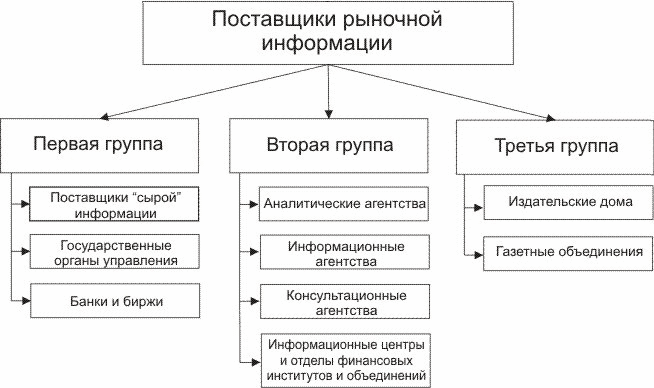

К первой группе относятся следующие:

- поставщики "сырой" финансовой информации - финансовые институты и службы, дающие первичную и оперативную биржевую и другую информацию;
- государственные органы управления, такие как ЦБ РФ и Министерство финансов РФ;
- банки, биржи.

Вторую группу составляют аналитические, информационные и консультационные агентства, информационные центры и отделы финансовых институтов и объединений.

Среди них: РосБизнесКонсалтинг (РБК) https://www.rbc.ru/; Акционерное общество "Анализ, консультации и маркетинг" (АК&М) https://www.akm.ru/; ; Информационное агентство "Финмаркет" http://www.finmarket.ru/; Агентство экономической информации "ПРАЙМ-ТАСС" https://1prime.ru/; Общество с ограниченной ответственностью МФД "ИнфоЦентр" https://mfd.ru/; Агентство Интерфакс https://www.interfax.ru/; Агентство экономических новостей (АЭН) https://www.myeconomy.ru/; и др.

Третью группу образуют издательские дома и газетные объединения, такие как "Финансовая газета" https://www.gazeta.ru/tags/media/finansovaya_gazeta.shtml, "Экономика и жизнь" https://www.eg-online.ru/, Издательский дом "Коммерсантъ" https://www.kommersant.ru/, ИТАР-ТАСС https://tass.ru/ и др.

## Управление ИР - аналитика больших данных

Скорость роста генерируемых и хранимых данных растет экспоненциально. В статье 1965 года Гордон Мур подсчитал, что плотность транзисторов на интегральной плате увеличивается вдвое каждые два года. Этот темп роста, известный как «закон Мура», был применен ко всем аспектам вычислений, от тактовых частот до памяти. Считается, что темпы роста объемов данных превышают закон Мура.

**Объемы данных увеличиваются более чем вдвое каждые восемнадцать месяцев.**

Этот взрыв данных создает возможности для новых способов комбинирования и использования данных, а также создает значительные проблемы из-за размера обрабатываемых и анализируемых данных.

Одно существенное изменение касается количества неструктурированных данных. Исторически структурированные данные обычно были в центре внимания большей части корпоративной аналитики, и обрабатывалась с помощью реляционной модели данных.

В последнее время количество неструктурированных данные, такие как веб-страницы, данные социальных сетей, изображения и видео резко выросли, и тенденция указывает на увеличение использования неструктурированных данных.

*Аналитика больших данных - это способность обрабатывать большие объемы и различные типы информации.*

Рассмотрим ключевые этапы в становлении понятия "большие данные" (https://api.bigdata-msu.ru/media/uploads/2021/05/27/2021_05_25_hohlov.pdf):

*2001.* Аналитик Meta Group Даг Лэйни публикует аналитическую записку, в которой дает три основные характеристики: объем, скорость изменений и многообразие больших данных (3V = Volume, Velocity, Variety)

*2013-2014*. Национальный институт стандартизации и технологий США (NIST) создает рабочую группу по большим данным для стандартизации эталонной архитектуры больших данных. В 2014 г опубликованы первые редакции основных документов NIST https://bigdatawg.nist.gov/V1_output_docs.php

*2015* Международная организация по стандартизации (ИСО) и Международная электротехническая комиссия (МЭК) публикуют предварительный доклад «Большие данные», в котором описаны проблемы и направления международной стандартизации технологий работы с большими данными.

*2018* Утверждены первые международные стандарты из серии стандартов ISO/IEC 20547-X, посвященной стандартизации эталонной архитектуры больших данных: часть 2 «Сценарии использования и производные требования» и часть 5 «Направления стандартизации»

*2020* Утвержден международный стандарт «Организация сетей, ориентированных на большие данные – Требования» [ITU-T Y.3652] и опубликованы рекомендации по внедрению больших данных в развивающихся странах [Y Suppl. 65], утверждены международные стандарты «Большие данные – Эталонная архитектура» [ITU-TY.3605] и «Большие данные – Обзор и требования к сохранению данных» [ITU-T Y.3604]

*2021* Подготовлен к публикации международный стандарт «Организация сетей, ориентированных на большие данные – Функциональная архитектура» [ITU-T Y.3653]

Для того чтобы набор данных можно было считать большими данными, он должен обладать одной или несколькими специфическими характеристиками. Большинство этих характеристик данных были первоначально определены Дагом Лейни в начале 2001 года, когда он опубликовал свою статью, описывающую влияние объема, скорости и многообразия данных электронной коммерции на хранилища данных предприятия.

На текущий момент согласно NIST SP 1500-1 -- Volume 1: Definitions выделяют следующие характеристики:

**Объем (Volume)**

Предполагаемый объем данных, который обрабатывается решениями для больших данных, является существенным и постоянно растущим. Большие объемы данных накладывают различные требования по хранению и обработке данных, а также к дополнительной подготовке данных, к процессам сопровождения и управления.

Типичные источники данных, которые отвечают за генерацию больших объемов данных, могут включать в себя:

- онлайн-транзакции, такие как розничные точки продаж и т.д.
- научные и исследовательские эксперименты, такие как большой адронный коллайдер и атакамский большой антенный телескоп
- сенсоры, такие как GPS-сенсоры, RFID, смарт-счетчики и телематика
- социальные сети, такие как Facebook и Twitter

  Организации и пользователи по всему миру создают более 2,5 ЕВ [экзабайтов) данных в день. В качестве сравнения: в настоящее время библиотека Конгресса США содержит более 300 ТВ (терабайтов) данный.

**Скорость (Velocity)**

В средах с большими данными последние могут поступать с высокими скоростями, и при этом огромные массивы данных могут накапливаться за очень короткие промежутки времени.

В зависимости от источника данных скорость может разной. В тоже время для сравнения можно указать, что за минуту могут быть легко созданы следующие объемы данных: 350 тысяч твитов, 300 часов видеоматериалов, загруженных на YouTube, 171 миллион электронных писем и 330 гигабайт данных от сенсоров реактивного двигателя.

**Многообразие (Variety)**

Многообразие данных касается множества форматов и типов данных, которые должны поддерживаться решениями для больших данных.

Многообразие данных создает проблемы с точки зрения интеграции данных, их трансформации, обработки и хранения. В качестве примера многообразия данных можно указать: структурированные данные в форме финансовых транзакций, слабоструктурированные данные в виде электронных писем и неструктурированные данные в виде изображений, текстов, графики, видео- аудио-, html, json, сенсорные данные и метаданные.

**Изменчивость (Variability)**

Кроме того, что данные могут быстро накапливаться, уже накопленные могут еще и быстро меняться. Это накладывает существенные ограничения на проектирование распределенных систем хранения данных, поскольку можно не успевать их согласовывать в разных сегментах децентрализованного хранилища: системы электронной коммерции, биржи.

Поскольку все эти термины начинаются на английскую букву V, такой набор часто называют "V".

В тоже время иногда выделяют дополнительные характеристики: **достоверность (veracity)** (т.е. точность данных), ценность **value** (т.е. ценность аналитики для организации), **волатильность (volatility)** (т. е. склонность структур данных к изменению во времени - меняются форматы хранения, передачи данных) и **валидность (validity)** (т. е. пригодность данных для предполагаемого использования).

Окончательно, под большими данными будем понимать:

**Большие данные - это данные, которые характеризуются следующими свойствами: объем, многообразие, скорость, и (или) изменчивость, и требуют масштабируемой архитектуры для эффективного хранения, обработки и анализа.**

Как уже было указано, по многообразию данные можно классифицировать на следующие группы:

- структурированные данные;
- слабоструктурированные данные;
- неструктурированные данные.

*Структурированные данные* соответствуют моделям или схемам данных и часто хранятся в табличных формах.

Они используются для фиксации отношений между различными объектами и поэтому чаще всего хранятся в реляционных базах данных. Структурированные данные часто генерируются корпоративными приложениями и информационными системами, такими как системы ERP и CRM. Из-за обилия инструментов и баз данных, которые поддерживают структурированные данные, они редко нуждаются в особых подходах к обработке или хранению. Примерами такого типа данных являются банковские операции, счета-фактуры и записи клиентов.

*Слабоструктурированные данные* имеют определенный уровень структуры и согласованности, но не являются реляционными по своей природе. Они являются иерархическими или основанными на графах. Такого рода данные обычно хранятся в файлах, содержащих текст. Например, файлы XML и JSON являются распространенными формами слабоструктурированных данных. Ввиду текстовой природы этих данных и их соответствия определенному уровню структуры они обрабатываются легче, чем неструктурированные данные. Примеры общих источников слабоструктурированных данных включают файлы электронной системы документооборота (EDI), электронные таблицы, RSS-каналы и данные от сенсоров. Слабоструктурированные данные часто имеют специальные требования к предварительной обработке и хранению, особенно если основной формат не является текстовым. Примером предварительной обработки слабоструктурированных данных может быть проверка допустимости XML-файла с целью гарантирования соответствия его определению схемы. (см. витрины данных https://data.mos.ru/)

*Данные, которые не соответствуют моделям или схемам данных, называются* неструктурированными данными*. Считается, что неструктурированные данные составляют 80% данных любой организации. Неструктурированные данные имеют более быстрый темп роста, чем структурированные. Форма таких данных является либо текстовой, либо бинарной и зачастую передается посредством файлов, которые являются автономными и нереляционными. Текстовый файл может вмещать содержимое различных твитов или постов в блогах. Бинарные файлы чаще представляют собой мультимедийные файлы, содержащие изображения, аудио- или видеоданные. Технически и текстовые, и бинарные файлы имеют структуру, определенную самим форматом файла, но этот аспект игнорируется, а понятие неструктурированное относится к формату данных.

Обычно для обработки и хранения неструктурированных данных требуется специализированная логика. Например, для воспроизведения видеофайла важно наличие правильного кодека. Неструктурированные данные нельзя напрямую обработать или запросить с помощью SQL. Если их необходимо хранить в реляционной базе данных, то они сохраняются в таблице как большие бинарные объекты (Binary Large Object — BLOB).

Рассмотрим теперь термин **наука о данных**. Согласно NIST:

**Наука о данных - это методология синтеза полезных знаний непосредственно из данных через процесс открытия или формулировки гипотез и проверки гипотез.**

*Специалист по данным (data scientist)* - это практик, обладающий достаточными знаниями в предметной области (Domain Expertise), статистики и машинном обучении (Statistics & Machine Learning), инжиниринга для управления сквозными процессами обработки данных в жизненном цикле данных (Engineering).

Более наглядно этот набор компетенций описан на рисунке в виде диаграммы Вена-Эйлера.

[figure not shown]

Хотя этот полный набор навыков в редком случае может присутствовать в отдельном человеке, также возможно, что эти навыки охватываются членами команды.

Анализ данных представляет собой процесс исследования данных для поиска фактов, отношений, шаблонов, идей и/или тенденций. Общая цель анализа данных заключается в том, чтобы поддерживать принятие более обоснованных решений. Простым примером анализа данных является анализ данных по продаже мороженого с целью определить, каким образом количество проданных рожков связано со среднесуточной температурой воздуха. Результаты такого анализа могли бы стать обоснованием для решения о количестве мороженого, которое магазин должен заказать в зависимости от прогноза погоды. Выполнение анализа данных помогает установить закономерности и взаимосвязи между анализируемыми данными.

Существуют четыре основные категории аналитики, которые различаются производимыми результатами:

- дескриптивная аналитика
- диагностическая аналитика
- прогностическая аналитика
- прескриптивная аналитика

*Дескриптивная аналитика*

Дескриптивная аналитика используется для поиска ответов на вопросы о событиях, которые уже произошли. Эта форма аналитики согласовывает данные с контекстом для генерирования информации. Примеры вопросов дескриптивной аналитики:

Каким был объем продаж за последние 12 месяцев? Сколько звонков поступило в службу поддержки, упорядоченных по категориям серьезности и географическому расположению? Какова ежемесячная комиссия, заработанная каждым агентом по продажам?

По оценкам, 80 % сгенерированных результатов аналитики являются дескриптивными по своей природе. Ориентированная на смысловую полезность, дескриптивная аналитика обеспечивается с наименьшими затратами и требует относительного базового набора навыков.

Дескриптивная аналитика часто выполняется с помощью специальных отчетов или информационных панелей. Отчеты обычно статичны по своей природе и отображают исторические данные, которые представлены в форме таблиц или диаграмм.

*Диагностическая аналитика*

Диагностическая аналитика направлена на то, чтобы определить причину произошедшего события, используя вопросы, которые фокусируются на причинах этого события. Цель этого типа аналитики — определить, какая информация относится к данному явлению, чтобы дать возможность ответить на вопросы о том, почему это произошло.

К таким вопросам относятся:

Почему продажи первого предприятия были меньше, чем продажи второго? Почему в службу поддержки поступило больше звонков из восточного региона, чем из западного? Почему увеличилось число повторных госпитализаций пациентов за последние три месяца?

Диагностическая аналитика имеет большую значимость, чем дескриптивная, но требует более продвинутого набора навыков. Обычно диагностическая аналитика требует сбора данных из различных источников и хранения их в структуре, которая подвергается детальному анализу и свертыванию.

Результаты диагностической аналитики могут быть просмотрены с помощью инструментов интерактивной визуализации, которые позволяют пользователям определять тенденции и шаблоны. Выполнение запросов здесь значительно сложнее, чем в дескриптивной аналитике, и выполняются они на многомерных данных, содержащихся в системах аналитической обработки.

*Прогностическая аналитика*

Прогностическая аналитика проводится с целью определить результат события, которое может произойти в будущем. С помощью прогностической аналитики информация усиливается смысловым содержанием. Интенсивность и значимость ассоциативных связей формируют основу моделей, которые используются для создания будущих прогнозов на основе прошлых событий.

Важно учитывать, что у моделей, которые используются для прогностической аналитики, существуют неявные зависимости от условий, в которых происходили прошлые события. Если лежащие в основе причины изменяются, то и модели прогнозирования должны быть откорректированы.

Вопросы обычно формулируются с использованием обоснования «Что, если...», например:

Какова вероятность невозвращения клиентом кредита, если пропущен ежемесячный платеж? Каков процент эффективности лечения пациента, если вместо препарата А будет использоваться препарат В? Если клиент приобрел продукты А и В, каковы шансы, что он также купит продукт С?

Прогностическая аналитика призвана предсказать исход события, при этом прогнозы делаются на основе шаблонов, тенденций и исключений, найденных в исторических и текущих данных. Это может привести к выявлению как рисков, так и возможностей. Такой вид аналитики предполагает использование больших наборов данных, внутренних и внешних, и различных методов анализа этих данных. Эта аналитика обеспечивает высокую значимость результатов и требует еще более совершенного набора навыков, чем дескриптивная и диагностическая.

Как правило, инструменты прогностической аналитики используют лежащие в их основе абстрактные способы решения статистических сложных задач, предоставляя удобные для пользователя внешние интерфейсы.

*Прескриптивная аналитика*

Прескриптивная аналитика основывается на результатах прогностической аналитики, предписывая меры, которые должны быть предприняты. Акцент делается не только на том, какому предписанному варианту лучше всего следовать, но и почему.

Вопросы могут иметь следующий вид:

Какой из трех препаратов обеспечивает наилучшие результаты? Когда наилучше время для проведения определенной акции?

Прескриптивная аналитика представляет большую значимость, чем любые другие виды аналитики, и, соответственно, требует самого продвинутого набора навыков, а также специализированного программного обеспечения и инструментов. Благодаря ей рассчитываются различные результаты и предлагается оптимальный курс действий для каждого из них. Такая тактика переходит от пояснений к консультациям и может включать в себя моделирование различных сценариев.

Этот вид аналитики охватывает внутренние данные одновременно с внешними. Внутренние данные могут включать в себя текущие и исторические данные о продажах, информацию о клиентах, данные о продуктах и бизнес-правила. Внешние же могут содержать данные из социальных сетей, прогнозы погоды и демографические данные, подготовленные правительством.

Жизненный цикл аналитики больших данных можно разделить на следующие девять этапов:

1. Оценивание ситуации
2. Идентификация данных
3. Сбор и фильтрация данных
4. Извлечение данных
5. Проверка и очистка данных
6. Агрегирование и представление данных
7. Анализ данных
8. Визуализация данных
9. Использование результатов анализа

*Оценивание ситуации*

Анализ данных связан с формированием цели анализа, определения мотивации. Четкая формулировка цели позволит выбрать основные направления анализа еще до начала выполнения реальных практических задач анализа.

*Идентификация данных*

Этап идентификации данных посвящен определению наборов данных, необходимых для аналитических проектов и их источников.

Выявление наиболее широкого спектра источников данных может увеличить вероятность обнаружения скрытых закономерностей и корреляций.  
В зависимости от сферы деятельности и характера решаемых бизнес-задач, требуемые наборы данных и их источники могут быть внутренними и/или внешними для организации.

В случае внутренних наборов данных, списки доступных наборов данных из внутренних источников, таких как витрины данных, базы данных, составляются и сравниваются с заранее определенной спецификацией набора данных.

При работе с внешними наборами данных составляется список возможных сторонних поставщиков, таких как витрины данных и общедоступные наборы данных. Некоторые формы внешних данных могут быть встроены в блоги или другие типы веб-сайтов на основе контента, и в этом случае они, возможно, должны быть собраны с помощью автоматизированных инструментов.

*Сбор и фильтрация данных*

На этапе сбора и фильтрации данных данные собираются из всех источников, которые были идентифицированы на предыдущем этапе. Затем полученные данные подвергаются автоматизированной фильтрации для удаления поврежденных или таких, которые не имеют особого значения для целей анализа.

В зависимости от типа источника данные могут поступать как набор файлов, например, данные, приобретенные у стороннего поставщика, или могут потребовать интеграции API, например, с Twitter. Во многих случаях, особенно в случае внешних неструктурированных данных, некоторые или большинство полученных данных могут быть нерелевантными (шумом) и могут быть отброшены в процессе фильтрации.

Данные, классифицированные как «искаженные», могут включать записи с отсутствующими или бессмысленными значениями или недопустимыми типами данных. Данные, отфильтрованные для одного анализа, могут быть значимыми для другого типа анализа. Поэтому рекомендуется сохранить точную копию исходного набора данных перед началом фильтрации. Чтобы свести к минимуму требуемое пространство для хранения, точная копия может быть сжата.

*Извлечение данных*

Некоторые данные, идентифицированные как входные данные для анализа, могут поступать в формате, несовместимом с алгоритмами обработки данных. Необходимость обращаться к несопоставимым типам данных более вероятна при работе с данными из внешних источников.

Этап жизненного цикла извлечения данных предназначен для извлечения несопоставимых данных и преобразования их в сопоставимый формат, который может использовать в целях анализа данных.

Необходимая степень извлечения и преобразования зависят от типов аналитики. Например, извлечение обязательных полей из текстовых данных с разделителями, таких как файлы журнала веб-сервера, может не понадобиться, если базовые решения для больших данных уже могут напрямую обрабатывать эти файлы.

Аналогично, извлечение текста для аналитики текста, который требует сканирования всех документов, упрощается, если базовое решение для больших данных может напрямую читать документ в его собственном формате.

*Проверка и очистка данных*

Неправильные данные могут искажать и фальсифицировать результаты анализа. В отличие от традиционных корпоративных данных, где структура данных заранее определена и данные предварительно проверены, данные вводимые в анализ больших данных могут быть неструктурированными, без каких-либо указаний на достоверность. Эта сложность также может затруднить получение набора подходящих ограничений проверки.

Этап проверки и очистки данных предназначен для создания зачастую сложных правил проверки и удаления любых известных недопустимых данных.

*Агрегирование и представление данных*

Данные могут быть распределены по нескольким наборам данных, требуя объединения наборов данных через общие поля, например дату или идентификатор (ID).

Этап агрегирования и представления данных предназначен для интеграции нескольких наборов данных вместе для достижения унифицированного представления.

*Анализ данных*

Этап анализа данных посвящен выполнению фактической задачи анализа, которая обычно включает в себя один или несколько типов аналитики. Этот этап может быть итеративным по своей природе, особенно если анализ данных является разведывательным — в этом случае анализ повторяется до тех пор, пока не будет обнаружен соответствующий шаблон или корреляция.

В зависимости от типа требуемого аналитического результата этот этап может быть таким же простым, как запрос к набору данных, чтобы вычислить агрегирование для сравнения. С другой стороны, это может быть столь же сложным, как комбинирование интеллектуального анализа данных и сложных методов статистического анализа для обнаружения закономерностей и аномалий, или для создания статистической или математической модели, описывающей взаимосвязи между переменными.

Анализ данных может быть классифицирован как *подтверждающий или разведывательный анализ*, последний из которых связан с data mining.

*Подтверждающий анализ* данных является дедуктивным подходом, при котором причина исследуемого явления предлагается заранее. Предлагаемая причина или предположение называется гипотезой. Затем данные анализируются для того, чтобы подтвердить или опровергнуть гипотезу и дать окончательные ответы на конкретные вопросы.

*Разведывательный анализ* данных представляет собой индуктивный подход, который тесно связан с data mining. Ни одна из гипотез или предположений не генерируются заранее. Вместо этого данные анализируются для развития понимания причины этого явления. Хотя анализ может и не давать окончательных ответов, этот метод позволяет сформировать направление, которое может способствовать обнаружению закономерностей или аномалий.

*Визуализация данных*

Способность анализировать огромные объемы данных и находить полезные идеи не имеет большого значения, если единственными, кто может интерпретировать результаты, являются аналитики.

Этап визуализации данных посвящен использованию методов визуализации данных и инструментам графического представления результатов анализа для их эффективной интерпретации пользователями.

*Использование результатов анализа*

После получения результатов анализа, предоставляемых пользователям для поддержки принятия решений, они могут располагаться на информационных панелях. Этап использования результатов анализа посвящен определению того, как и где обрабатываемые аналитические данные могут быть в дальнейшем использованы.

Анализ больших данных сочетает традиционные методы статистического анализа данных с вычислительными методами.

Принято выделять общие и частные методы анализа больших данных.

Среди общих методов следует выделить:

- количественный анализ
- качественный анализ
- Data Mining (интеллектуальный анализ данных)

Внутри Data Mining часто говорят про следующие методы:

- статистический анализ
- машинное обучение
- семантический анализ
- визуальный анализ

*Количественный анализ* — это метод анализа данных, который фокусируется на определении количественных закономерностей и корреляций, найденных в данных. Основанный на статистических методах, этот метод предполагает анализ большого количества наблюдений из набора данных. Поскольку размер выборки большой, результаты могут применяться обобщенно ко всему набору данных.

Результаты количественного анализа носят абсолютный характер и поэтому могут использоваться для численных сравнений. Например, количественный анализ по продажам мороженого может обнаружить, что увеличение температуры на 5 градусов увеличивает продажи мороженого на 15%.

*Качественный анализ* — это метод анализа данных, который фокусируется на описании различных качеств данных с использованием слов.

Он предполагает анализ меньшей выборки, но более основательнее, по сравнению с количественным анализом данных. Такие результаты анализа не могут быть обобщены на весь набор данных из-за небольшого размера выборки. Их также нельзя численно измерить или использовать для числовых сравнений. Например, качественный анализ по продажам мороженого может показать, что показатели продаж в мае были не такими высокими, как в июне. Результаты анализа указывают только на то, что цифры «не так высоки, как», и не дают количественной разницы. Результатом качественного анализа является описание отношения с использованием слов.

*Data Mining*

Data Mining (интеллектуальный анализ данных), известен также как обнаружение данных, представляет собой специализированную форму анализа данных, предназначенную для больших наборов данных. В связи с анализом больших данных, Data Mining обычно относится к автоматизированным, основанным на программном обеспечении методам, которые просеивают массивные наборы данных для выявления закономерностей и тенденций.

В частности, это предполагает извлечение скрытых или неизвестных шаблонов в данных с целью идентификации ранее неизвестных закономерностей. Data Mining является основой для прогностической аналитики и Business Intelligence (BI).

*Статистический анализ*

Статистический анализ использует статистические методы, основанные на теории вероятностей и математической статистики в качестве средства для анализа данных. Статистический анализ чаще всего является количественным, но может быть и качественным.

Этот тип анализа обычно используется для описания наборов данных посредством итогового обобщения, например, предоставление среднего значения. Среди важных методов можно указать следующие виды статистического анализа:

- проверка статистических гипотез
- корреляционный анализ
- регрессионный анализ

*Машинное обучение*

Люди хорошо разбираются в шаблонах и отношениях внутри данных. К сожалению, мы не можем обработать большие объемы данных очень быстро. Машины, с другой стороны, очень искусны в быстрой обработке больших объемов данных, но только тогда, когда знают как.

Если знания человека сочетать со скоростью обработки машины, то последние смогут обрабатывать большие объемы данных, без особого вмешательства человека. Это и является основной концепцией машинного обучения.

В Data Mining можно выделить следующие важные методы машинного обучения:

- Классификация
- Кластеризация
- Обнаружение выбросов
- Фильтрация

*Классификация* — это метод обучения с учителем, при котором данные классифицируются на релевантные, заранее исследованные категории.  
Данный метод состоит из двух этапов:

1. Система получает обучающие данные, которые уже классифицированы или промаркированы, для возможности развития понимания различных категорий.
2. Система получает неизвестные, но аналогичные данные для классификации, и на основании понимания, которое она получила из обучающих данных, алгоритм классифицирует немаркированные данные.

   Примером применения этого метода является фильтрация спама электронной почты.

   Классификация может проводиться по двум или более категориям.

   Примеры вопросов, которые можно решать с использованием классификации:
- Следует ли принять или отклонить заявку претендента на выдачу кредитной карты на основании других принятых или отклоненных заявок?
- Является ли томат фруктом или овощем, основываясь на известных примерах фруктов и овощей?
- Результаты клинических испытаний для пациентов свидетельствуют об угрозе сердечного приступа?

  Для классификации используют целый арсенал математических подходов (методов, алгоритмов): опорные вектора, градиентный бустинг, деревья решений, нейронные сети и т.д.

*Кластеризация* — это метод обучения без учителя, при котором данные делятся на разные группы, так что данные в каждой группе имеют схожие свойства. Не требуется никакого предварительного изучения требуемых категорий. Вместо этого категории генерируются неявно на основе группирования данных. Способ группирования данных зависит от типа используемого алгоритма. Каждый алгоритм использует различную технику для определения кластеров.

Кластеризация обычно используется в Data Mining для получения представления о свойствах заданного набора данных. После разработки такого понимания классификация может использоваться для более точного прогнозирования подобных, но новых или ненаблюдаемых данных.

Кластеризация может применяться для категоризации неизвестных документов и персонализированных маркетинговых кампаний, группируя клиентов со схожим поведением.

Вопросы, решаемые в рамках кластеризации, могут включать в себя:

- Сколько существует различных видов деревьев, основываясь на сходстве между деревьями?
- Сколько существует групп клиентов, основываясь на истории аналогичных покупок?
- Какие различные группы вирусов, основываясь на их характеристиках?

  Для кластеризации также используют целый ряд математических методов и алгоритмов: k-means, иерархическая кластеризация, генетические алгоритмы, нейронные сети и т.д.

  *Обнаружение выбросов* — это процесс поиска данных, которые существенно отличаются от других данных в заданном наборе данных или несовместимы с ними. Этот метод машинного обучения используется для выявления аномалий, патологий и отклонений, которые либо следует исключить из рассмотрения при анализе или наоборот, обратить на них пристальное внимание при анализе возможных рисков.

  Обнаружение выбросов тесно связано с концепцией классификации и кластеризации, хотя алгоритмы и сосредоточены на поиске аномальных значений. Процесс может основываться либо на контролируемом, либо на неконтролируемом обучении.

  Приложения для обнаружения выбросов включают обнаружение мошенничества, медицинскую диагностику, анализ сетевых данных и анализ данных датчиков.

  Примеры вопросов могут включать в себя следующее:
- Является ли спортсмен тем, кто использовал допинговые препараты?
- Имеются ли неправильно идентифицированные фрукты и овощи в учебном наборе данных, который используется для задачи классификации?
- Существует ли особый штамм вируса, который не реагирует на лекарства?

*Фильтрация* - это автоматизированный процесс поиска релевантных элементов из совокупности всех элементов. Элементы могут быть отфильтрованы либо на основе собственного поведения пользователя, либо путем сопоставления поведения нескольких пользователей.

Фильтрация обычно применяется с помощью следующих двух подходов:

- коллаборативной фильтрации
- фильтрации на основе контента

  Широко распространённым средством для осуществления фильтрации, является использование рекомендационных систем.

Коллаборативная фильтрация — это один из методов построения прогнозов (рекомендаций) в рекомендательных системах, использующий известные предпочтения (оценки) группы пользователей для прогнозирования неизвестных предпочтений другого пользователя.

Фильтрация на основе контента — это метод фильтрации элементов, сфокусированный на сходстве между пользователями и элементами. Профиль пользователя создается на основе предыдущего поведения пользователя, например, его предпочтений, оценок и истории покупок. Сходства, выявленные между профилем пользователя и атрибутами различных элементов, приводит к элементам, которые фильтруются для пользователя. В противовес коллаборативной фильтрации, фильтрация на основе контента предназначена исключительно для индивидуальных предпочтений пользователя и не требует данных о других пользователях. Данный метод, например, используется для реализации контент-фильтра - устройство или программное обеспечение для фильтрации сайтов по их содержимому, не позволяющее получить доступ к определённым сайтам или услугам сети Интернет. Система позволяет блокировать веб-сайты с содержимым, не предназначенным для просмотра.

Примеры вопросов могут включать в себя:

- Как можно отображать только те новостные статьи, которые интересуют пользователя?
- Какие места для отдыха можно порекомендовать, основываясь на истории путешествий отдыхающего?
- Каких других новых пользователей можно предложить в качестве друзей на основе текущего профиля пользователя?

*Семантический анализ (Text Mining)*

Семантический анализ представляет собой практический метод извлечения значимой информации из текстовых и речевых данных.

Среди основные методов можно указать:

- распознавание голоса
- автоматизированное формирование резюме по тексту
- тематическая близость текстов
- распознавание эмоциональной окраски

*Визуальный анализ* является формой анализа данных, которая содержит графическое представление данных для обеспечения или улучшения их визуального восприятия. Основываясь на предположении, что людям проще и быстрее понять и сделать выводы из графиков, чем из текстов, визуальный анализ действует как инструмент обнаружения знаний в области больших данных.

Цель заключается в использовании графических представлений для более глубокого понимания анализируемых данных. В частности, это помогает выявлять и подчеркивать скрытые закономерности, корреляции и аномалии. Визуальный анализ также непосредственно связан с пробным анализом данных, поскольку он подходит с разных сторон к формулированию вопросов.

Среди методов визуального анализа можно указать:

- Цветовые карты
- Временные ряды
- Сетевые графики
- Сопоставление пространственных данных

  При обзоре программных средств следует говорить про два взаимосвязанных, но самостоятельных направления:
  1. программные средства создания и содержания инфраструктуры больших данных;
  2. программные средсва анализа больших данных.

В первом направлении нужно выделить фреймворк Hadoop (https://hadoop.apache.org/) для разработки и выполнения распределённых программ, работающих на кластерах из сотен и тысяч узлов.

Все началось в 2004 году, когда компания Google опубликовала статью, посвященную процессу MapReduce. Каркас MapReduce использует модель параллельной обработки очень большого объема данных. В рамках MapReduce запросы разделяются и распределяются по параллельным узлам, при этом они обрабатываются параллельно (этап распределения (Мар)). Затем осуществляется сбор и доставка результатов (этап преобразования (Reduce)).

Hadoop на данный момент является «де-факто» стандартом создания и обслуживания инфраструктры больших данных. Hadoop представляет собой фреймворк, на основе которого разрабатываются приложения для анализа и визуализации больших данных. Хранение данных в данном фреймворке осуществяляется с помощью специальной распределённой файловой системы HDFS (Hadoop Distributed File System), которая лежит в основе Hadoop и позволяет хранить и предоставлять доступ к данным сразу на нескольких узлах кластера. Таким образом, если один или несколько узлов кластера выходят из строя, то риск потери информации сводится к минимуму и кластер продолжает работу в штатном режиме.

В рамках второго направления существует огромное количество различных инструментов. Остановимся на ключевых из них:

**WEKA**

Weka ( https://www.cs.waikato.ac.nz/~ml/weka/ ), программное обеспечение с открытым исходным кодом, представляет собой набор алгоритмов машинного обучения для задач интеллектуального анализа данных. Алгоритмы могут быть применены непосредственно к набору данных или вызваны из вашего собственного Java-кода. Он также хорошо подходит для разработки новых схем машинного обучения, поскольку полностью реализован на языке программирования Java, а также поддерживает несколько стандартных задач интеллектуального анализа данных. Weka с ее графическим интерфейсом, обеспечивает самый простой переход в мир Data Science. Для пользователей с опытом программирования на Java есть возможность встраивать в библиотеку свой собственный код.

[figure not shown]

**Язык общего назначения Python (https://www.python.org/)**

Основные преимущества:

- Простой, но выразительный синтаксис.
- Богатый выбор библиотек. И речь не только о библиотеках алгоритмов машинного обучения — на Python разрабатывают облачные хранилища, стриминговые сервисы. Ниже перечислены некоторые из библиотек:
  - Pandas — библиотека для манипулирования данными с огромными возможностями. Позволяет очень быстро провести исследование новых данных, протестировать гипотезы, получить отчёт. Одно из главных преимуществ Python.
  - Scikit-learn — большая библиотека алгоритмов машинного обучения и обработки данных.
  - Keras и PyTorch — библиотеки, используемые для обучения глубоких нейронных сетей. Подходят для задач, связанных с изображениями, аудио и видео файлами.
  - IPython Notebook — рассказывая о Python нельзя не упомянуть о нём. Стандартная среда разработки не совсем подходит data scientist’у в процессе исследования данных. Есть потребность в таком формате, который позволил бы, например, запустить затратный алгоритм, а когда он завершится — поиграть немного с результатами, исследовать их и построить графики. Здесь на помощь и приходит формат ноутбука. Это графический интерфейс, который открывается в обычном браузере и представляет из себя последовательность ячеек, где можно писать и исполнять код, используя при этом общую память для хранения данных.
- Высокая культура документации. Сам Python прекрасно документирован, и обычно библиотеки на нём продолжают эту традицию.

**Язык статистических вычислений R (https://www.r-project.org/)**

В 2020 году язык R остаётся одним из самых популярных для Data Science и статистики, стабильно завоёвывая всё большую долю просмотров в соответствующих разделах StackOverflow. При этом, со значительным перевесом лидируют вопросы академического характера: в первую очередь, R — это язык с богатым набором библиотек по машинному обучению и статистике, что особенно важно в исследовательских целях.

Основные преимущества:

- Огромное количество библиотек статистических методов. R особенно популярен в академической среде, что и приводит к тому, что часто новые методы впервые имплементируются именно на нём.
- Достаточно удобная проприетарная среда разработки RStudio, с которой будет легко разобраться.
- Необычный синтаксис, заточенный под нужды статистики.
- Нативная поддержка векторных вычислений.

**Anaconda (https://www.anaconda.com/)**

Anaconda — дистрибутив языков программирования Python и R, включающий набор популярных свободных библиотек, объединённых проблематиками науки о данных и машинного обучения. Основная цель — поставка единым согласованным комплектом наиболее востребованных соответствующим кругом пользователей тематических модулей (таких как NumPy, SciPy, Astropy и других) с разрешением возникающих зависимостей и конфликтов.

[figure not shown]

**Сравнение Python и R**

Оба языка обладают своими достоинствами и недостатками. Подойти может любой из них, всё зависит от ваших задач. Вот некоторые моменты, которые могут помочь с выбором:

- При программировании Python гораздо более привычен.
  - Python больше приближен к продакшену и чаще применяется в коммерческих проектах. В то же время, в академических кругах большей популярностью пользуется R.
- Хотите ли вы расширить кругозор в методах машинного обучения? Или вам достаточно будет ознакомиться с несколькими наиболее популярными методами и больше времени посвятить, например, алгоритмам обработки больших данных? В первом случае вам однозначно нужен R, во втором — больше возможностей вы найдёте в Python.
  - Хотите ли вы заниматься внедрением своих разработок, и программировать что-либо? Если да, то Python вам подойдёт лучше, но скорее всего понадобится и что-то ещё (например Java, Scala или C++).